# Consumer Segmentation Using Cluster Analysis

Grouping Consumers of Office Equipment for Targeted Marketing

John Karuitha

Tuesday October 18, 2022

## Background

When procuring goods and services, consumers have a plethora of options. For instance, which vendor would best meet the consumer demands? Where should the consumers procure the goods and services? In this project, we examine the choice of vendor using `cluster analysis`. Specifically, we will use data from a survey of 200 respondents regarding the importance of several store attributes when choosing where to buy office equipment.

## Data

We start by reading the data into `R` and examining the first few rows.

```r
## Read the data
office <- read_csv("office (2).csv") %>%

        clean_names()
```

```r
office %>%

        head() %>%

        kbl(., booktabs = TRUE, caption = "First Six Observations of the Data") %>%

        kable_classic(full_width = TRUE)
```

First Six Observations of the Data

| respondent_id | variety_of_choice | electronics | furniture | quality_of_service | low_prices | return_policy | professional | income | age |
| --- | --- | --- | --- | --- | --- | --- | --- | --- | --- |
| 1 | 8 | 3 | 6 | 3 | 2 | 2 | non-professional | 16 | 28 |
| 2 | 6 | 3 | 1 | 4 | 7 | 1 | non-professional | 22 | 27 |
| 3 | 6 | 1 | 2 | 4 | 9 | 6 | non-professional | 18 | 22 |
| 4 | 8 | 3 | 3 | 4 | 8 | 7 | non-professional | 18 | 29 |
| 5 | 4 | 6 | 3 | 4 | 2 | 5 | professional | 35 | 51 |
| 6 | 8 | 4 | 3 | 5 | 10 | 6 | non-professional | 13 | 24 |

Variables Description

| Variable | Description |
| --- | --- |
| respondent_id | An identifier for our observations |
| variety_of_choice | Importance to customers of having a variety of choice in a store on a 0-10 scale |
| electronics | Importance of this attribute on a 0-10 scale |
| furniture | Importance furniture to consumers of on a 0-10 scale |
| quality_of_services | Importance of this attribute on a 0-10 scale |
| low_prices | Importance of this attribute on a 0-10 scale |
| return_policy | Importance of this attribute on a 0-10 scale |
| professional | Whether the respondent is a professional or not (e.g., student) |
| income | Gross annual income expressed in thousands of pound sterling |
| age | Respondents’ age in years |

## Data Visualisation

In this section e visualise the data and run correlation analysis. Figure 1 shows the pairs plot for all the variables in the data set. Some of the variables have very high correlation, for instance, `age` and `income` at 0.74 and `variety of choices` and `furniture` at 0.66. The main diagonal of the pairs plot shows that the variables are highly skewed.

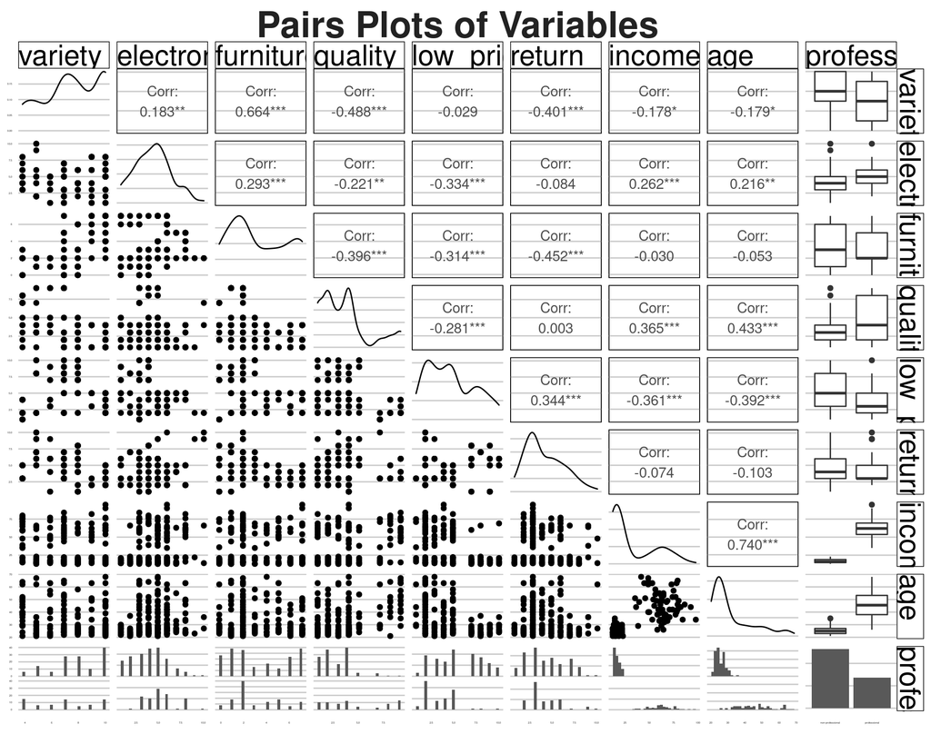

Pairs Plots of Variables

```r
## Pairs plots for all variables
office %>%

        select(-respondent_id) %>%

        relocate(professional, .after = age) %>%

        ggpairs(title = "Pairs Plots of Variables") +

        theme(axis.text = element_text(size = 2))
```

Figure 2 shows a visualisation of the correlations, showing the high degree of collinearity between some of the variables.

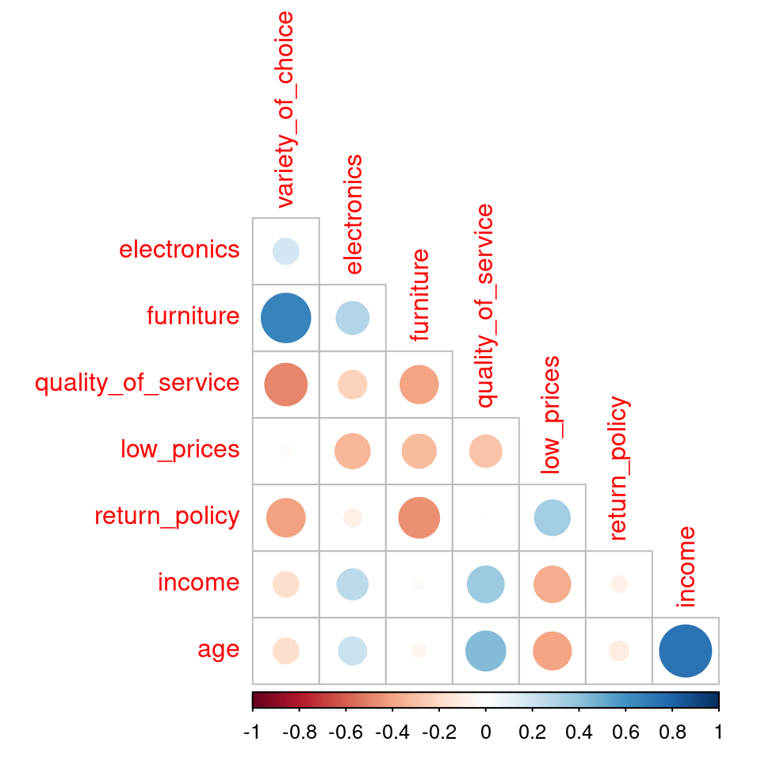

Correlation Matrix

```r
office %>%

        select(where(is.numeric), -respondent_id) %>%

        cor() %>%

        corrplot(type = "lower", diag = FALSE)
```

## Summary Statistics

```r
## Summary Statistics for numeric variables
office %>%

        select(where(is.numeric), -respondent_id) %>%

        skim_without_charts() %>%

        select(-skim_type, -n_missing) %>%

        rename(Variable = skim_variable, mean = numeric.mean,

               SD = numeric.sd, Min = numeric.p0,

               Q1 = numeric.p25, Median = numeric.p50,

               Q3 = numeric.p75, Max = numeric.p100) %>%

        kbl(., booktabs = TRUE, caption = "Summary Statistics for Numeric Variables") %>%

        kable_classic(full_width = TRUE)
```

Summary Statistics for Numeric Variables

| Variable | complete_rate | mean | SD | Min | Q1 | Median | Q3 | Max |
| --- | --- | --- | --- | --- | --- | --- | --- | --- |
| variety_of_choice | 1 | 7.6 | 2.0 | 4 | 6 | 8.0 | 10 | 10 |
| electronics | 1 | 4.5 | 1.9 | 1 | 3 | 4.5 | 6 | 10 |
| furniture | 1 | 3.3 | 2.4 | 0 | 1 | 2.0 | 6 | 7 |
| quality_of_service | 1 | 3.5 | 2.3 | 1 | 2 | 3.0 | 4 | 9 |
| low_prices | 1 | 4.8 | 2.5 | 1 | 2 | 5.0 | 7 | 10 |
| return_policy | 1 | 4.2 | 2.0 | 1 | 3 | 4.0 | 6 | 10 |
| income | 1 | 32.2 | 22.7 | 13 | 15 | 19.5 | 54 | 95 |
| age | 1 | 32.5 | 11.9 | 21 | 24 | 27.0 | 38 | 68 |

```r
office %>%

        select(where(is.character)) %>%

        skim() %>%

        kbl(., booktabs = TRUE, caption = "Summary of Character Variables") %>%

        kable_classic(full_width = TRUE)
```

Summary of Character Variables

| skim_type | skim_variable | n_missing | complete_rate | character.min | character.max | character.empty | character.n_unique | character.whitespace |
| --- | --- | --- | --- | --- | --- | --- | --- | --- |
| character | professional | 0 | 1 | 12 | 16 | 0 | 2 | 0 |